# Week 3: HW - Visualizing Air Quality Analysis

Loan Nguyen

1/11/23

# Instructions

Use the built-in `airquality` R dataset to visualize the air quality in 1973. Explore the patterns in the data by creating histograms, boxplots, line graphs, heatmaps, and scatterplots.

Load the libraries `ggplot2` and `reshape2` in the setup chunk below.

```r
library(ggplot2)
library(reshape2)
```

# Step 1 - Load the Data

We will use the `airquality` dataset that you have as part of your R installation. Read the `airquality` data using the `data.frame()` function and save it as `air`.

```r
air <- data.frame(airquality)
head(air)
```

```
##   Ozone Solar.R Wind Temp Month Day
## 1    41     190  7.4   67     5   1
## 2    36     118  8.0   72     5   2
## 3    12     149 12.6   74     5   3
## 4    18     313 11.5   62     5   4
## 5    NA      NA 14.3   56     5   5
## 6    28      NA 14.9   66     5   6
```

# Step 2 - Clean the Data

After you load the data, there will be some NA values in the data. You need to figure out what to do about those nasty NAs. Google is your friend. Use Google actively to find a way to get rid of NAs using R.

**HINT:** Find columns that include NA values first (use `colSums()` function, then replace NAs with the mean value of these columns).

Optional: If you want to implement a better approaches to deal with missing data, “multiple imputation” would be where you should go.  
You can check sources like:

- https://gking.harvard.edu/amelia
- http://cran.revolutionanalytics.com/web/packages/mitools/index.html

```r
colSums(air)
```

```
##   Ozone Solar.R    Wind    Temp   Month     Day
##      NA      NA  1523.5 11916.0  1070.0  2418.0
```

```r
air$Ozone[is.na(air$Ozone)] <- mean(air$Ozone, na.rm = T)
air$Solar.R[is.na(air$Solar.R)] <- mean(air$Solar.R, na.rm = T)
head(air)
```

```
##      Ozone  Solar.R Wind Temp Month Day
## 1 41.00000 190.0000  7.4   67     5   1
## 2 36.00000 118.0000  8.0   72     5   2
## 3 12.00000 149.0000 12.6   74     5   3
## 4 18.00000 313.0000 11.5   62     5   4
## 5 42.12931 185.9315 14.3   56     5   5
## 6 28.00000 185.9315 14.9   66     5   6
```

# Step 3 - Understand the data distribution

Create the following visualizations:

- Histograms for each of the variables
- Boxplot for `Ozone`, and boxplots for different `wind` values (round `wind` to get a good number of “buckets”)

**HINT:** you can create one graph with `Ozone` as X-axis and `Wind` as Y-axis. Also, you can create two graphs (one with `Ozone` values on the Y-axis, and another one with Y-axis value is rounded value of `Wind`). In this case, you need to create a fake grouping variable `(x = factor(0))`.

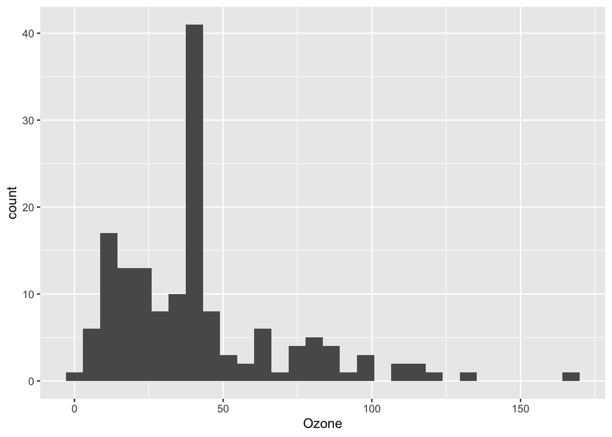

```r
ggplot(air, aes(Ozone)) + geom_histogram()
```

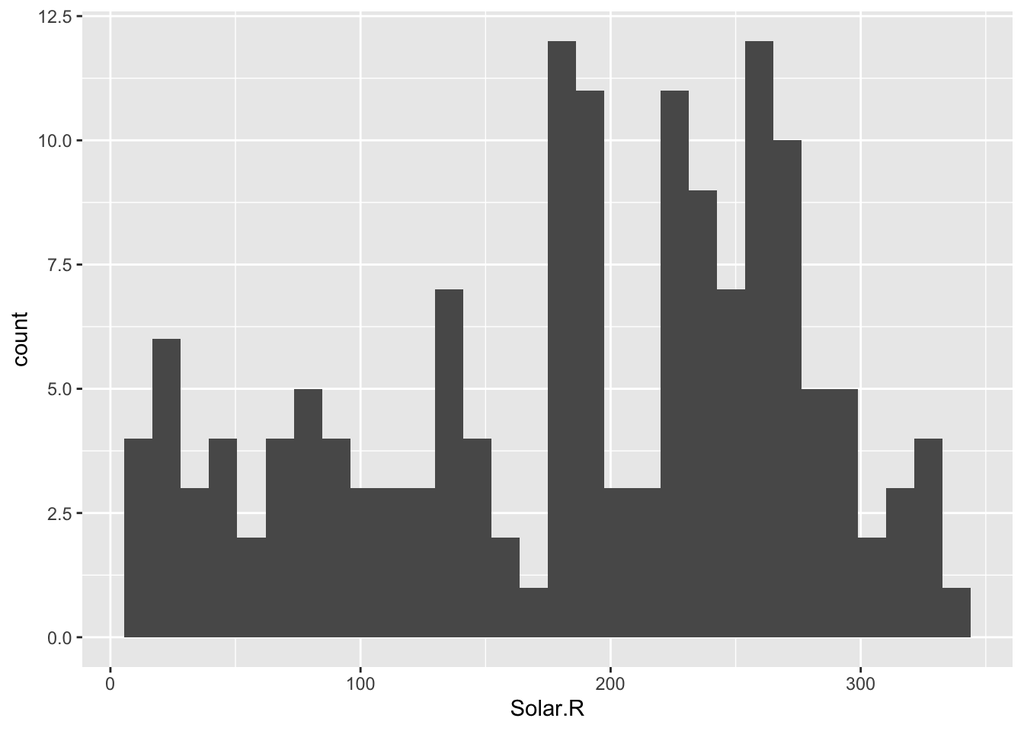

```r
ggplot(air, aes(Solar.R)) + geom_histogram()
```

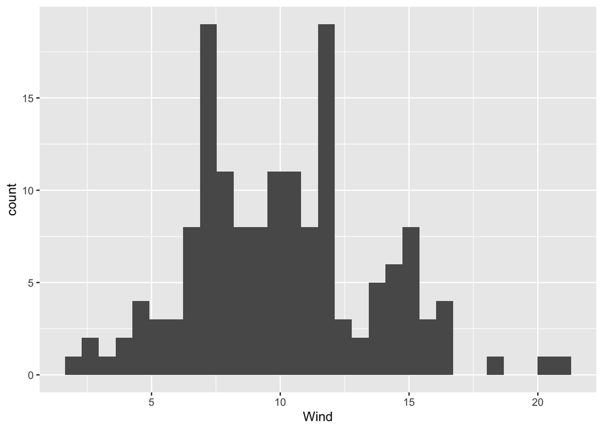

```r
ggplot(air, aes(Wind)) + geom_histogram()
```

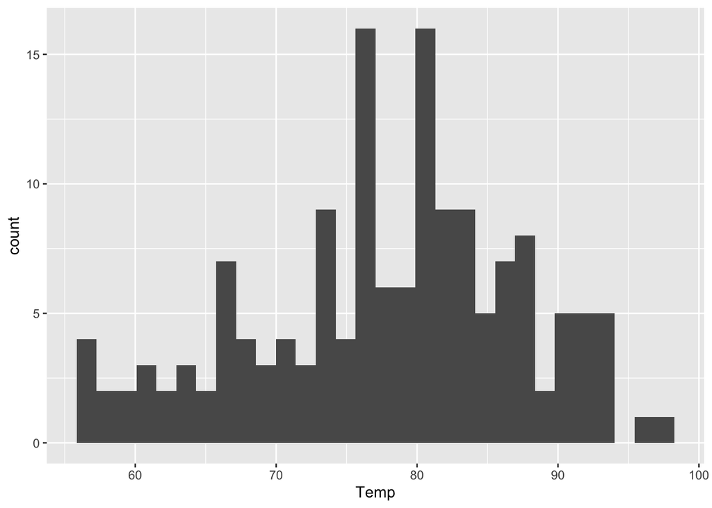

```r
ggplot(air, aes(Temp)) + geom_histogram()
```

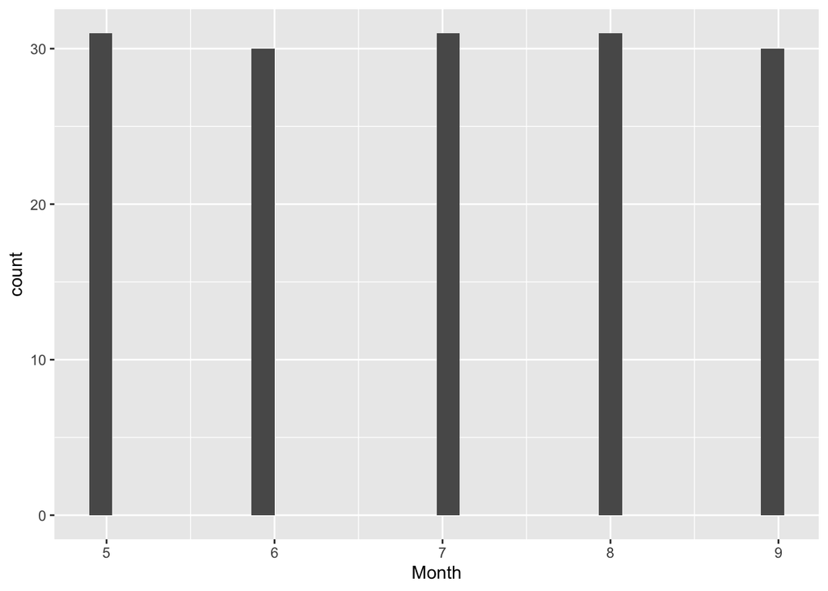

```r
ggplot(air, aes(Month)) + geom_histogram()
```

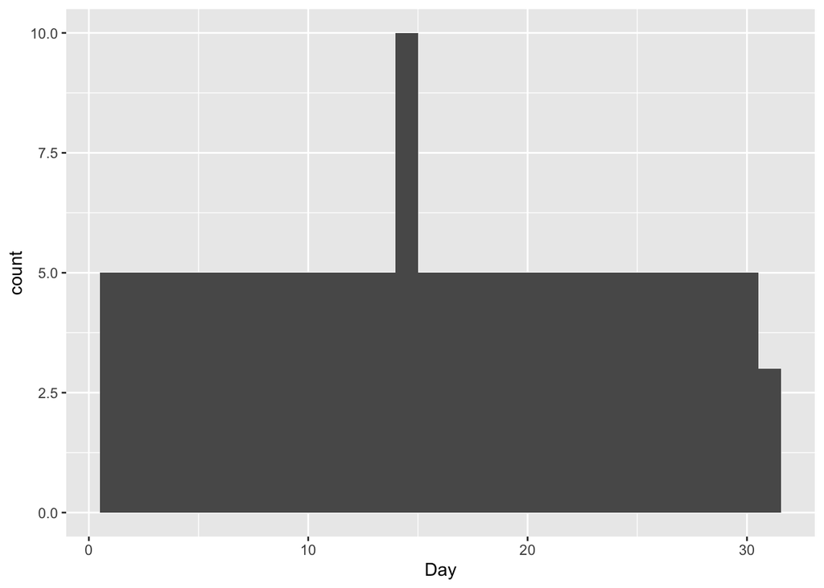

```r
ggplot(air, aes(Day)) + geom_histogram()
```

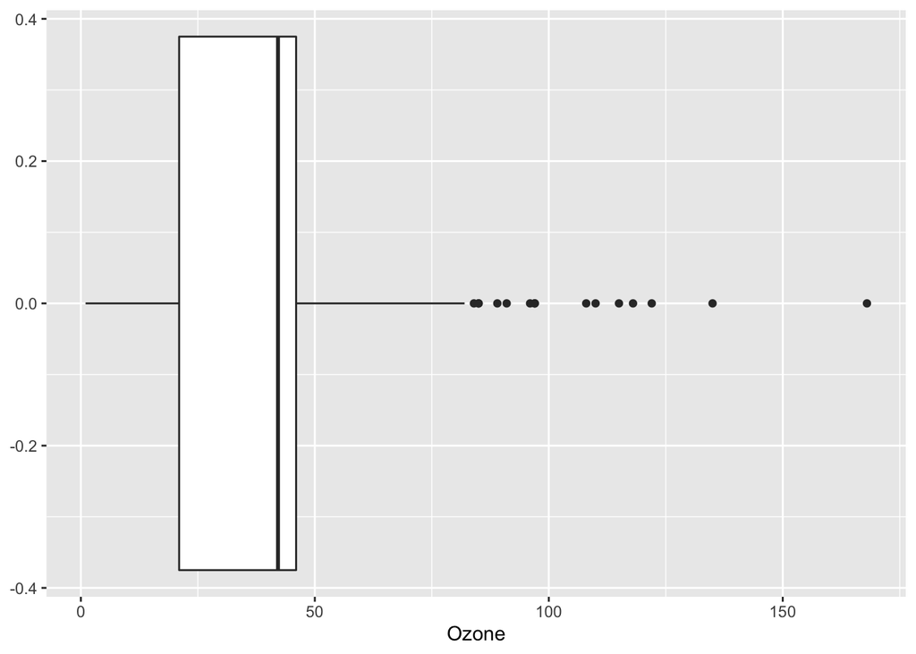

```r
ggplot(air, aes(Ozone)) + geom_boxplot()
```

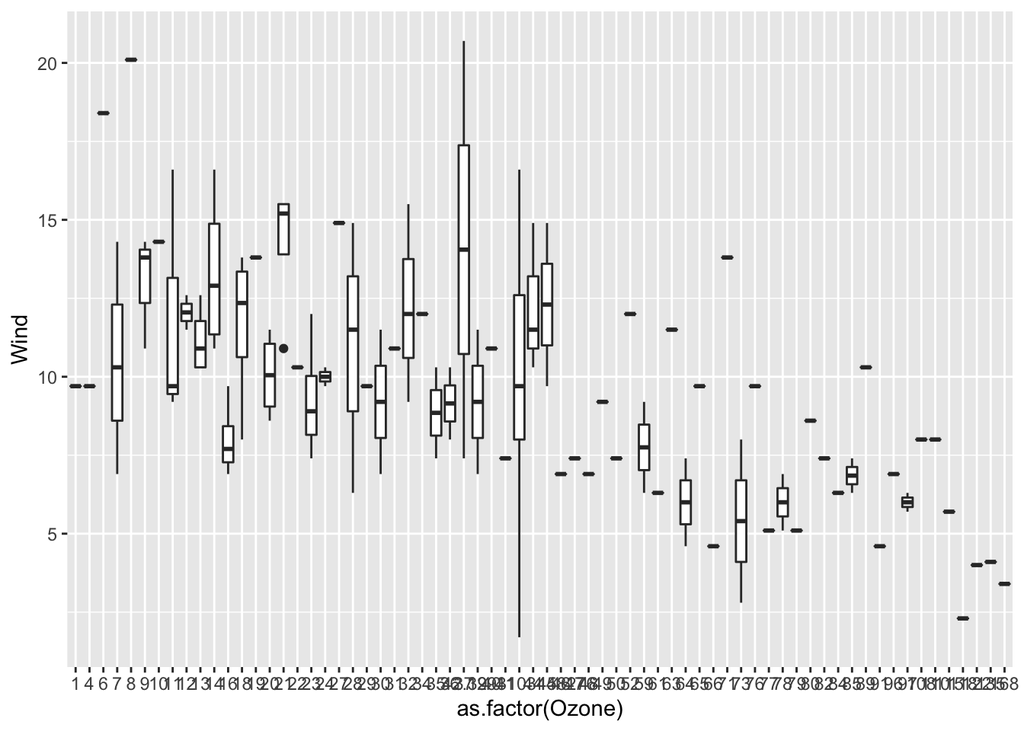

```r
ggplot(air, aes(as.factor(Ozone), Wind)) + geom_boxplot()
```

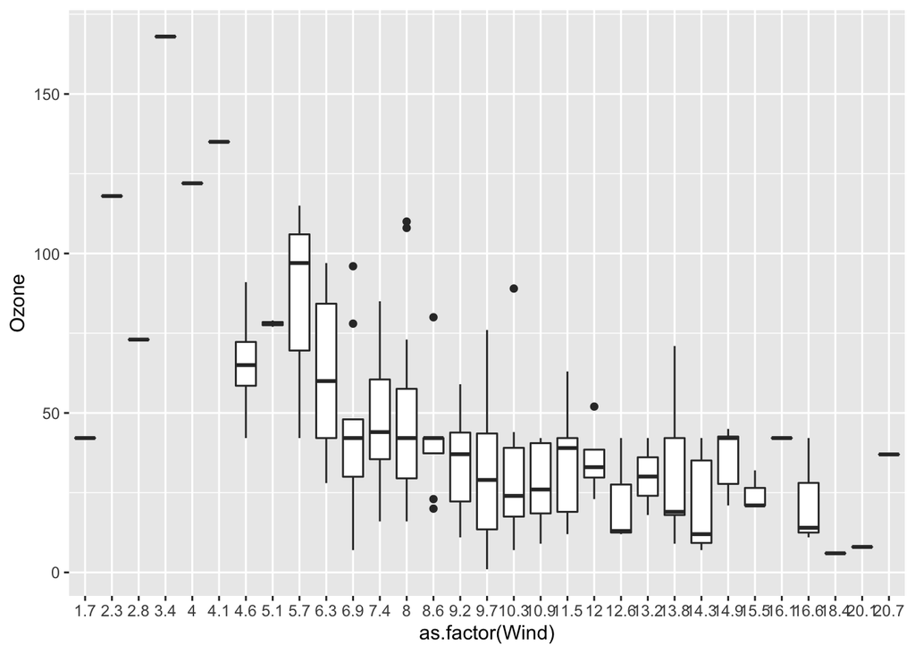

```r
ggplot(air, aes(as.factor(Wind), Ozone)) + geom_boxplot()
```

# Step 4 - Explore how the data changes over time

First, create the appropriate dates (this data was from 1973). Then create line charts for `Ozone`, `Temp`, `Wind` and `Solar.R` (one line chart for each, and then one chart with 4 lines, each variable having a different color).

**HINT:**

1. Combine (use `paste()` function) 1973 with the `Month` and `Day` columns, using “/” in between
2. Use `as.Date()` function to transform the value to “Date” format and create a `Date` column to record this value. Use `?as.Date` to find example use of this function.

Note that for the chart with 4 lines, you need to think about how to effectively use the y-axis.

**HINT:** You need to “melt” the columns so that it becomes “long” format. You can either use the `melt()` function or use the `gather()` from the “tidyr” package for the process. Also, compared to other values, the `Wind` values are too small, so they are close to the x-axis. You need to multiply `Wind` by 10 to address this problem.

The correct result should look like this:

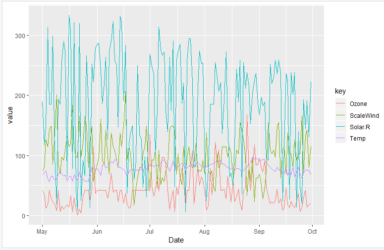

```r
air$Date <- as.Date(paste("1973", air$Month, air$Day, sep = "/"))
air$Wind <- air$Wind * 10
head(air)
```

```
##      Ozone  Solar.R Wind Temp Month Day       Date
## 1 41.00000 190.0000   74   67     5   1 1973-05-01
## 2 36.00000 118.0000   80   72     5   2 1973-05-02
## 3 12.00000 149.0000  126   74     5   3 1973-05-03
## 4 18.00000 313.0000  115   62     5   4 1973-05-04
## 5 42.12931 185.9315  143   56     5   5 1973-05-05
## 6 28.00000 185.9315  149   66     5   6 1973-05-06
```

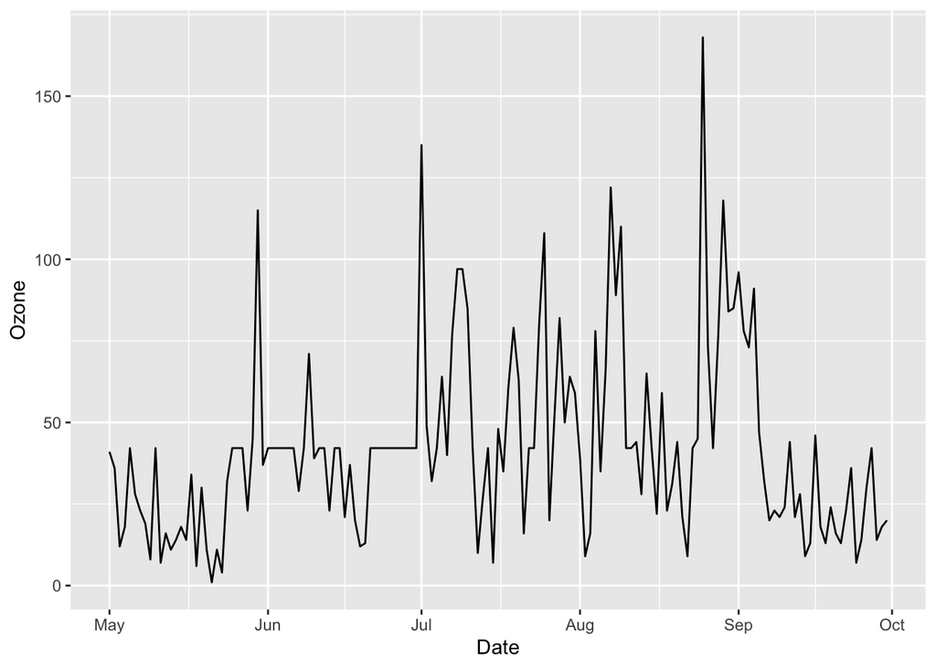

```r
ggplot(air, aes(Date, Ozone)) + geom_line()
```

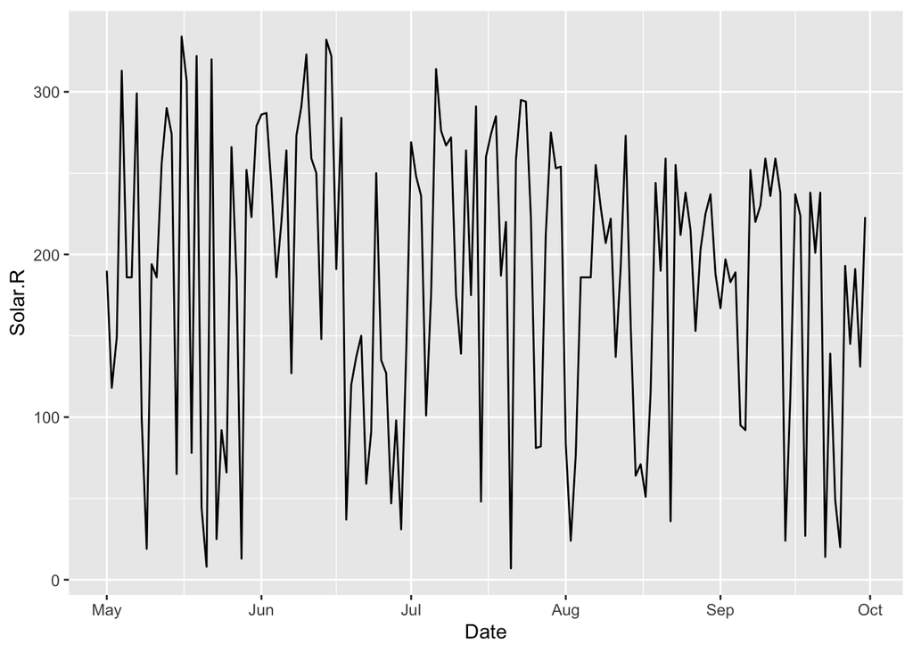

```r
ggplot(air, aes(Date, Solar.R)) + geom_line()
```

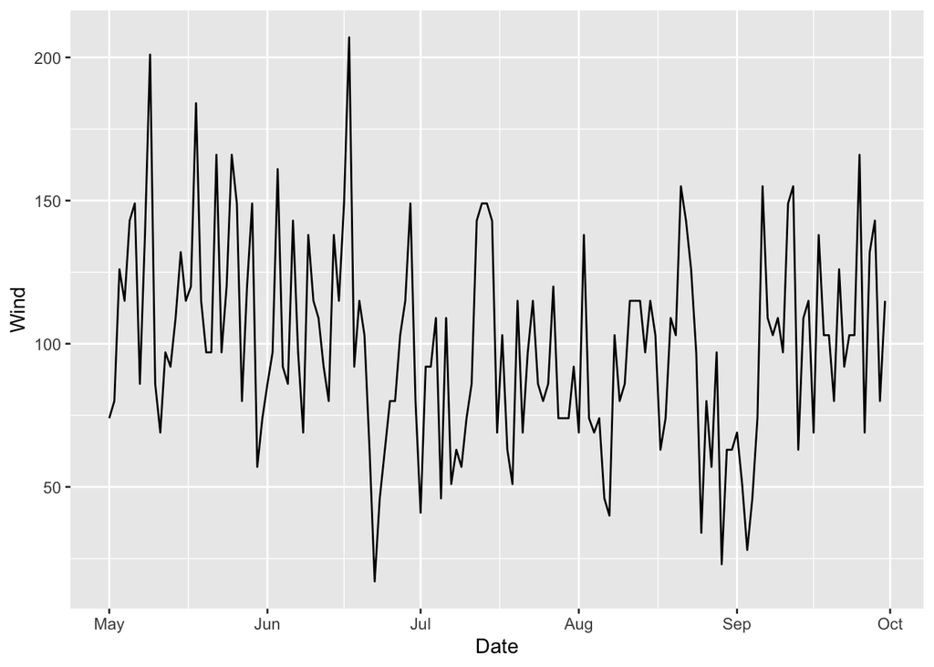

```r
ggplot(air, aes(Date, Wind)) + geom_line()
```

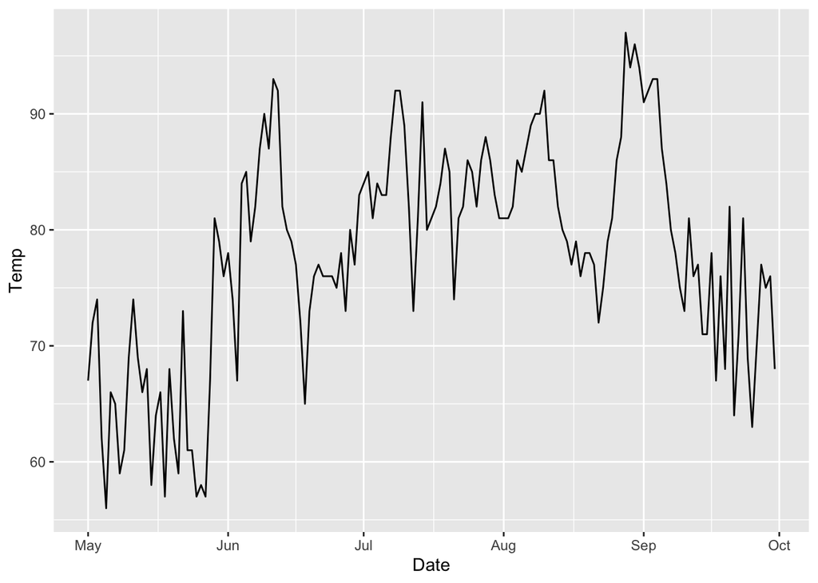

```r
ggplot(air, aes(Date, Temp)) + geom_line()
```

```r
air2 <- data.frame(air$Ozone, air$Solar.R, air$Wind, air$Temp, air$Date)
air2 <- air[,c("Ozone", "Solar.R", "Wind", "Temp", "Date")]
head(air2)
```

```
##      Ozone  Solar.R Wind Temp       Date
## 1 41.00000 190.0000   74   67 1973-05-01
## 2 36.00000 118.0000   80   72 1973-05-02
## 3 12.00000 149.0000  126   74 1973-05-03
## 4 18.00000 313.0000  115   62 1973-05-04
## 5 42.12931 185.9315  143   56 1973-05-05
## 6 28.00000 185.9315  149   66 1973-05-06
```

```r
melted <- melt(air2, id = "Date")
head(melted)
```

```
##         Date variable    value
## 1 1973-05-01    Ozone 41.00000
## 2 1973-05-02    Ozone 36.00000
## 3 1973-05-03    Ozone 12.00000
## 4 1973-05-04    Ozone 18.00000
## 5 1973-05-05    Ozone 42.12931
## 6 1973-05-06    Ozone 28.00000
```

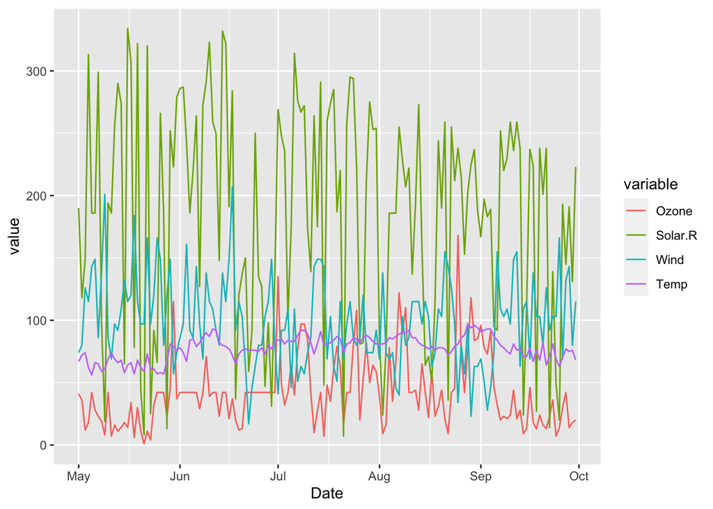

```r
ggplot(melted, aes(Date, value, color = variable)) +
  geom_line()
```

# Step 5: Look at all the data via a heatmap

Create a heatmap, with each day (using dates) along the x-axis and `Ozone`, `Temp`, `Wind` and `Solar.r` along the y-axis.

Note that you need to figure out how to show the relative change equally across all the variables.

**HINTS:** - You may find this post helpful: - https://learnr.wordpress.com/2010/01/26/ggplot2-quick-heatmap-plotting/ - Melt the original table to make a long format before visualization using `geom_tile()`

Remember, your programming skills will improve as much as you struggle and put effort in them.

The correct result should look like this:

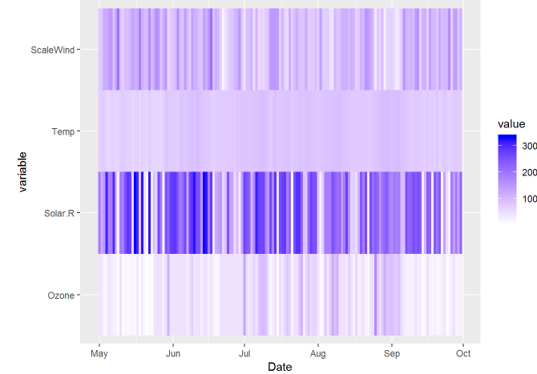

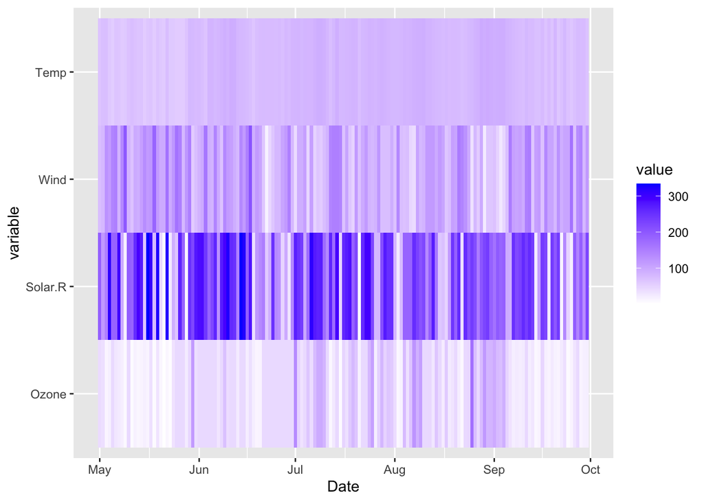

```r
ggplot(melted, aes(Date, variable)) +
  geom_tile(aes(fill = value)) +
  scale_fill_gradient(low = "white", high = "blue")
```

# Step 6: Look at all the data via a scatter chart

Create a scatter chart, with: - the x-axis representing the `Wind` - the y-axis representing the `Temp` - the size of each dot representing the `Ozone` - the color representing `Solar.R`

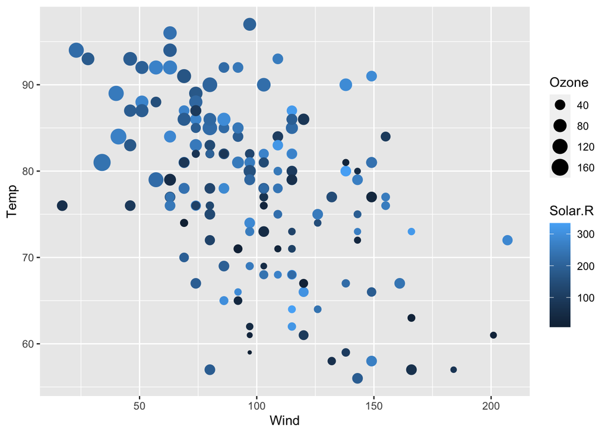

```r
ggplot(air, aes(Wind, Temp)) + geom_point(aes(size = Ozone, color = Solar.R))
```

# Step 7: Final analysis

### You MUST answer to these questions in your compiled file.

Do you see any patterns after exploring the data?

> Prof.’s response: One of the most prominent patters I notice is the fluctuations in the variables throughout the year. Almost each month has a point where the ozone level reaches its peak, then fluctuates again until it reaches another peak the following month. Ozone levels appear to gradually increase until September. According to the line chart, the wind, and solar levels also appear to fluctuate. The temperature remains mostly steady throughout the year aside from minor fluctuations. I also notice that the points with low ozone levels also tend to have a lower Solar.R value. Many of the points with lower wind values also have higher Solar.R and ozone levels.

What was the most useful visualization?

> As I can see how variables are compared over time using a multiline chart, I think it is ideal for this data.

> Prof.’s response: I think that the most useful visualizations were the multiline chart and the scatter chart. The multiline chart was useful because it clearly showed the change in the variables over time. The scatter chart was useful because it was easy to see the relationships between Solar.R, Ozone, and Wind values with the point colors and point sizes. It was also easy to see at what values most of the points clustered around.